# tt_astronauts

This is another tidy tuesday dataset wrangling. Inspired by: https://www.youtube.com/watch?v=rzfTA3xi-W0&t=1248s

## Download the dataset

```r
astronauts <- readr::read_csv("https://raw.githubusercontent.com/rfordatascience/tidytuesday/master/data/2020/2020-07-14/astronauts.csv")

# download file
download.file("https://raw.githubusercontent.com/rfordatascience/tidytuesday/master/data/2020/2020-07-14/astronauts.csv", "data/astronauts.csv")
```

```r
library(tidyverse)
```

## Check out the data set

```r
glimpse(astronauts)
```

```
Rows: 1,277
Columns: 24
$ id                       <dbl> 1, 2, 3, 4, 5, 6, 7, 8, 9, 10, 11, 12...
$ number                   <dbl> 1, 2, 3, 3, 4, 5, 5, 6, 6, 7, 7, 7, 8...
$ nationwide_number        <dbl> 1, 2, 1, 1, 2, 2, 2, 4, 4, 3, 3, 3, 4...
$ name                     <chr> "Gagarin, Yuri", "Titov, Gherman", "G...
$ original_name            <chr> "ГАГАРИН Юрий Алексеевич", "ТИТОВ Гер...
$ sex                      <chr> "male", "male", "male", "male", "male...
$ year_of_birth            <dbl> 1934, 1935, 1921, 1921, 1925, 1929, 1...
$ nationality              <chr> "U.S.S.R/Russia", "U.S.S.R/Russia", "...
$ military_civilian        <chr> "military", "military", "military", "...
$ selection                <chr> "TsPK-1", "TsPK-1", "NASA Astronaut G...
$ year_of_selection        <dbl> 1960, 1960, 1959, 1959, 1959, 1960, 1...
$ mission_number           <dbl> 1, 1, 1, 2, 1, 1, 2, 1, 2, 1, 2, 3, 1...
$ total_number_of_missions <dbl> 1, 1, 2, 2, 1, 2, 2, 2, 2, 3, 3, 3, 2...
$ occupation               <chr> "pilot", "pilot", "pilot", "PSP", "Pi...
$ year_of_mission          <dbl> 1961, 1961, 1962, 1998, 1962, 1962, 1...
$ mission_title            <chr> "Vostok 1", "Vostok 2", "MA-6", "STS-...
$ ascend_shuttle           <chr> "Vostok 1", "Vostok 2", "MA-6", "STS-...
$ in_orbit                 <chr> "Vostok 2", "Vostok 2", "MA-6", "STS-...
$ descend_shuttle          <chr> "Vostok 3", "Vostok 2", "MA-6", "STS-...
$ hours_mission            <dbl> 1.77, 25.00, 5.00, 213.00, 5.00, 94.0...
$ total_hrs_sum            <dbl> 1.77, 25.30, 218.00, 218.00, 5.00, 51...
$ field21                  <dbl> 0, 0, 0, 0, 0, 0, 0, 0, 0, 0, 0, 0, 0...
$ eva_hrs_mission          <dbl> 0.00, 0.00, 0.00, 0.00, 0.00, 0.00, 0...
$ total_eva_hrs            <dbl> 0.00, 0.00, 0.00, 0.00, 0.00, 0.00, 0...
```

Each observation (row) is one astronaut per mission. Duplicates per name and mission.

## Purpose

Ambition: Build a model to predictive model to predict how long a person was on that mission based on the information of the mission. So we want to build a regression model using hours_mission as response variable.

Method: Bagging (bootstrap aggregating)

## EDA

| name | n |
| --- | --- |
| Chang-Diaz, Franklin R. | 7 |
| Ross, Jerry L. | 7 |
| Brown, Curtis L., Jr. | 6 |
| Foale, C. Michael | 6 |
| Krikalev, Sergei | 6 |
| Malenchenko, Yuri | 6 |
| Musgrave, Franklin Story | 6 |
| Wetherbee, James D. | 6 |
| Young, John W. | 6 |
| Blaha, John E. | 5 |

[output cut: 554 more lines]

Check out the time people have spent in space, this has evolved over time

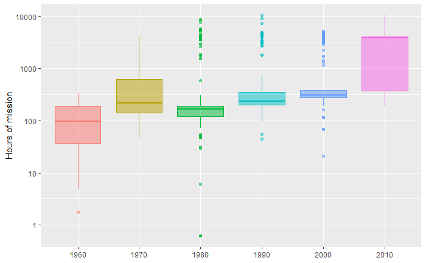

We want to predict the y axis. How long were astronauts in space. The median time in space is going up from the 60s and 70s to the 10s. We will model the y on the log scale that we have in the plot. We see that time affects it already in this. We will use bagging.

## Build dataset for modelling

Select some of the features for the modelling (not all this time)

| name | mission_title | hours_mission | military_civilian | occupation | year_of_mission | in_orbit |
| --- | --- | --- | --- | --- | --- | --- |
| Gagarin, Yuri | Vostok 1 | 0.5709795 | military | pilot | 1961 | Vostok 2 |
| Titov, Gherman | Vostok 2 | 3.2188758 | military | pilot | 1961 | Vostok 2 |
| Glenn, John H., Jr. | MA-6 | 1.6094379 | military | pilot | 1962 | MA-6 |
| Glenn, John H., Jr. | STS-95 | 5.3612922 | military | PSP | 1998 | STS-95 |
| Carpenter, M. Scott | Mercury-Atlas 7 | 1.6094379 | military | Pilot | 1962 | Mercury-Atlas 7 |
| Nikolayev, Andriyan | Vostok 3 | 4.5432948 | military | pilot | 1962 | Vostok 3 |
| Nikolayev, Andriyan | Soyuz 9 | 6.0497335 | military | pilot | 1970 | Soyuz 9 |
| Popovich, Pavel | Vostok 4 | 4.2616935 | military | pilot | 1962 | Vostok 4 |
| Popovich, Pavel | Soyuz 14 | 5.9322452 | military | commander | 1974 | Soyuz 14 |
| Schirra, Walter M., Jr. | Mercury-Atlas 8 | 2.2213750 | military | pilot | 1962 | Mercury-Atlas 8 |

[output cut: 990 more lines]

```r
astronauts_df
```

## Build model

Using tidymodels

```r
library(tidymodels)
```

```r
astro_splits <- initial_split(astronauts_df, strata = hours_mission) # stratified sampling with hours_misison equal in the bins
astro_splits
```

```
<Analysis/Assess/Total>
<954/316/1270>
```

We have split the data into astro_train and astro_test. The hours_mission is the one we are going to predict. This is on log scale.

Some data preprocessing using recipe.

```r
recipe(hours_mission ~., data = astro_train) %>%
  update_role(name, mission_title, new_role = "id") %>%
  # these two variable are not predictors or outcome
  step_other(occupation, in_orbit, other = "other")
```

```
Data Recipe

Inputs:
```

| role | #variables |
| --- | --- |
| id | 2 |
| outcome | 1 |
| predictor | 4 |

```
Operations:

Collapsing factor levels for occupation, in_orbit
```

| name | mission_title | year_of_mission | hours_mission | military_civilian_military | occupation_flight.engineer | occupation_msp | occupation_other..space.tourist. | occupation_pilot | occupation_psp | occupation_other | in_orbit_Mir | in_orbit_Mir.EP | in_orbit_Salyut | in_orbit_STS | in_orbit_other |
| --- | --- | --- | --- | --- | --- | --- | --- | --- | --- | --- | --- | --- | --- | --- | --- |
| Titov, Gherman | Vostok 2 | 1961 | 3.2188758 | 1 | 0 | 0 | 0 | 1 | 0 | 0 | 0 | 0 | 0 | 0 | 1 |
| Glenn, John H., Jr. | MA-6 | 1962 | 1.6094379 | 1 | 0 | 0 | 0 | 1 | 0 | 0 | 0 | 0 | 0 | 0 | 1 |
| Glenn, John H., Jr. | STS-95 | 1998 | 5.3612922 | 1 | 0 | 0 | 0 | 0 | 1 | 0 | 0 | 0 | 0 | 1 | 0 |
| Carpenter, M. Scott | Mercury-Atlas 7 | 1962 | 1.6094379 | 1 | 0 | 0 | 0 | 1 | 0 | 0 | 0 | 0 | 0 | 0 | 1 |
| Nikolayev, Andriyan | Vostok 3 | 1962 | 4.5432948 | 1 | 0 | 0 | 0 | 1 | 0 | 0 | 0 | 0 | 0 | 0 | 1 |
| Nikolayev, Andriyan | Soyuz 9 | 1970 | 6.0497335 | 1 | 0 | 0 | 0 | 1 | 0 | 0 | 0 | 0 | 0 | 0 | 1 |
| Popovich, Pavel | Vostok 4 | 1962 | 4.2616935 | 1 | 0 | 0 | 0 | 1 | 0 | 0 | 0 | 0 | 0 | 0 | 1 |
| Schirra, Walter M., Jr. | Gemini 6A | 1965 | 3.2530840 | 1 | 0 | 0 | 0 | 0 | 0 | 0 | 0 | 0 | 0 | 0 | 1 |
| Schirra, Walter M., Jr. | Apollo 7 | 1968 | 5.5611815 | 1 | 0 | 0 | 0 | 0 | 0 | 0 | 0 | 0 | 0 | 0 | 1 |
| Cooper, L. Gordon, Jr. | Mercury-Atlas 9 | 1963 | 3.5357283 | 1 | 0 | 0 | 0 | 1 | 0 | 0 | 0 | 0 | 0 | 0 | 1 |

[output cut: 944 more lines]

prep() means estimated, juice() means get the data back. ..ISS is the default level, that is why it is not seen as a dummy variable

Now data has been pre-processed.

Modelling - bagging models using the baguette package. It is like a modelling averaging method. The benfit of using this instead of just one model, it reduced overfitting and variance. We will take the dataset and create new bootstrap training datasets using resampling with replacement. We will draw with replacement from the 954 observations training dataset. We will then fit a model to each one of the bootstrap samples. Then we will combine by averaging the input because this is a regression model. Classification combine by voting.

```r
library(baguette)
```

Let´s create a workflow with baguette

```r
astro_wf
```

```
== Workflow ====================================================================
Preprocessor: Recipe
Model: None

-- Preprocessor ----------------------------------------------------------------
2 Recipe Steps

* step_other()
* step_dummy()
```

Notice that it has recipe steps but it does not have a model yet.

Now we make our model

```r
tree_spec
```

```
Bagged Decision Tree Model Specification (regression)

Main Arguments:
  cost_complexity = 0
  min_n = 2

Engine-Specific Arguments:
  times = 25

Computational engine: rpart
```

rpart is a bagged decision tree. times = 25 says we will create 25 boot strap training set and train a model on each set_mode regression means we average the 25 models together to get the prediction

Then we do another model

```r
mars_spec
```

```
Bagged MARS Model Specification (regression)

Engine-Specific Arguments:
  times = 25

Computational engine: earth
```

this is a different kind of bagged model We have two different types of models that we can bag together The model specs work in slightly different ways.

Now add model to workflow

```r
tree_rs
```

```
== Workflow [trained] ==========================================================
Preprocessor: Recipe
Model: bag_tree()

-- Preprocessor ----------------------------------------------------------------
2 Recipe Steps

* step_other()
* step_dummy()

-- Model -----------------------------------------------------------------------
```

| term | value | std.error | used |
| --- | --- | --- | --- |
| year_of_mission | 849.09032 | 20.766351 | 25 |
| in_orbit_other | 538.23475 | 53.592577 | 25 |
| in_orbit_STS | 325.70831 | 25.927707 | 25 |
| occupation_flight.engineer | 237.98015 | 27.035443 | 25 |
| in_orbit_Mir | 155.67307 | 22.427610 | 25 |
| occupation_pilot | 116.36842 | 18.410583 | 25 |
| occupation_msp | 109.36912 | 11.510911 | 25 |
| in_orbit_Salyut | 80.10400 | 8.406766 | 25 |
| occupation_psp | 41.32290 | 8.245314 | 25 |
| military_civilian_military | 41.28850 | 2.460239 | 25 |

[output cut: 3 more lines]

```
Bagged CART (regression with 25 members)

Variable importance scores include:
```

| term | value | std.error | used |
| --- | --- | --- | --- |
| year_of_mission | 849.09032 | 20.766351 | 25 |
| in_orbit_other | 538.23475 | 53.592577 | 25 |
| in_orbit_STS | 325.70831 | 25.927707 | 25 |
| occupation_flight.engineer | 237.98015 | 27.035443 | 25 |
| in_orbit_Mir | 155.67307 | 22.427610 | 25 |
| occupation_pilot | 116.36842 | 18.410583 | 25 |
| occupation_msp | 109.36912 | 11.510911 | 25 |
| in_orbit_Salyut | 80.10400 | 8.406766 | 25 |
| occupation_psp | 41.32290 | 8.245314 | 25 |
| military_civilian_military | 41.28850 | 2.460239 | 25 |

[output cut: 3 more lines]

```
NA
```

This ia bagged CART regression model with 25 members. It gives our aggregated variable importance score. Most important thing is the year_of_mission, next is about space craft the other category then the space shutle (STS).

Do the same for the mars model

```r
# training 25 models
mars_rs <- astro_wf %>%
  add_model(mars_spec) %>% # now model is included in wf
  fit(astro_train) # we fit the model on the training dataset
```

```r
mars_rs
```

```
== Workflow [trained] ==========================================================
Preprocessor: Recipe
Model: bag_mars()

-- Preprocessor ----------------------------------------------------------------
2 Recipe Steps

* step_other()
* step_dummy()

-- Model -----------------------------------------------------------------------
```

| term | value | std.error | used |
| --- | --- | --- | --- |
| in_orbit_STS | 99.8622974 | 0.1377026 | 25 |
| in_orbit_other | 93.8979480 | 1.6149255 | 25 |
| year_of_mission | 72.5980119 | 4.3282033 | 25 |
| in_orbit_Salyut | 29.6370730 | 1.3955105 | 25 |
| in_orbit_Mir.EP | 28.1347703 | 1.6396829 | 25 |
| occupation_other | 6.2311133 | 1.1924899 | 14 |
| military_civilian_military | 3.2150271 | 0.5340863 | 12 |
| occupation_flight.engineer | 1.5835140 | 0.8021837 | 4 |
| occupation_pilot | 1.4480151 | 0.6138634 | 7 |
| occupation_psp | 0.7710697 | 0.4947617 | 4 |

[output cut: 1 more lines]

```
Bagged MARS (regression with 25 members)

Variable importance scores include:
```

| term | value | std.error | used |
| --- | --- | --- | --- |
| in_orbit_STS | 99.8622974 | 0.1377026 | 25 |
| in_orbit_other | 93.8979480 | 1.6149255 | 25 |
| year_of_mission | 72.5980119 | 4.3282033 | 25 |
| in_orbit_Salyut | 29.6370730 | 1.3955105 | 25 |
| in_orbit_Mir.EP | 28.1347703 | 1.6396829 | 25 |
| occupation_other | 6.2311133 | 1.1924899 | 14 |
| military_civilian_military | 3.2150271 | 0.5340863 | 12 |
| occupation_flight.engineer | 1.5835140 | 0.8021837 | 4 |
| occupation_pilot | 1.4480151 | 0.6138634 | 7 |
| occupation_psp | 0.7710697 | 0.4947617 | 4 |

[output cut: 1 more lines]

```
NA
```

It is training 25 models, when we predict it will average them together. All 25 models are in this mars_rs object.

We get slightly different results compared to the tree results. In both methods the same three terms are on top but the order is different between them. Next we evalute the models.

## Evaluate models

Let´s look at our test data and compare these two modelling methods.

| name | mission_title | hours_mission | military_civilian | occupation | year_of_mission | in_orbit | .pred_tree | .pred_mars |
| --- | --- | --- | --- | --- | --- | --- | --- | --- |
| Gagarin, Yuri | Vostok 1 | 0.5709795 | military | pilot | 1961 | Vostok 2 | 3.097420 | 3.011808 |
| Popovich, Pavel | Soyuz 14 | 5.9322452 | military | commander | 1974 | Soyuz 14 | 4.317131 | 5.201668 |
| Schirra, Walter M., Jr. | Mercury-Atlas 8 | 2.2213750 | military | pilot | 1962 | Mercury-Atlas 8 | 2.857938 | 3.304221 |
| Bykovsky, Valery | Soyuz 22 | 5.2417470 | military | commander | 1976 | Soyuz 22 | 5.678312 | 5.029151 |
| Bykovsky, Valery | Soyuz 31/29 | 5.2364420 | military | commander | 1978 | Salyut | 5.235527 | 6.341291 |
| Belyayev, Pavel | Voskhod 2 | 3.2592497 | military | commander | 1965 | Voskhod 2 | 4.085768 | 4.125656 |
| Leonov, Aleksei | Voskhod 2 | 3.2592497 | military | pilot | 1965 | Voskhod 2 | 4.522277 | 4.181461 |
| Leonov, Aleksei | Soyuz 19 | 4.9558271 | military | commander | 1975 | Soyuz 19/Apollo | 5.480330 | 5.055676 |
| Lovell, James A., Jr. | Gemini 12 | 4.5432948 | military | commander | 1966 | Gemini 12 | 4.150823 | 4.305510 |
| Stafford, Thomas P. | gemini 6A | 3.2526974 | military | pilot | 1965 | gemini 6A | 4.522277 | 4.181461 |

[output cut: 306 more lines]

We have these two different predictions each of them created using bootstrap aggregation of different kinds of modelling methodologies. We can now find metrics for them.

| .metric | .estimator | .estimate |
| --- | --- | --- |
| rmse | standard | 0.6516205 |
| rsq | standard | 0.7626547 |
| mae | standard | 0.3516000 |

This outputs rmse, rsq(r2) and mae (mean absolute error) Let´s look at the mars model.

[output not shown]

```r
test_rs %>% metrics(hours_mission, .pred_mars)
```

It looks like the mars-model i a little bit better. At least with these defaults that we used. That is our model performance.

We can also use this to understand what kind of predictions the bagged models are making. Lets make some new astrounatus by using the functions crossing()

| in_orbit | military_civilian | occupation | year_of_mission | name | mission_title |
| --- | --- | --- | --- | --- | --- |
| ISS | civilian | other | 2000 | id | id |
| ISS | civilian | other | 2010 | id | id |
| ISS | civilian | other | 2020 | id | id |
| STS | civilian | other | 1980 | id | id |
| STS | civilian | other | 1990 | id | id |
| STS | civilian | other | 2000 | id | id |
| STS | civilian | other | 2010 | id | id |
| Mir | civilian | other | 1990 | id | id |
| Mir | civilian | other | 2000 | id | id |
| Mir | civilian | other | 2010 | id | id |

[output cut: 8 more lines]

crossing() gives us every combination of those variable values.

Now we do predictions for the new_astronauts

| .pred |
| --- |
| 6.613980 |
| 6.457792 |
| 6.077660 |
| 7.243241 |
| 6.602953 |
| 6.434311 |
| 6.208518 |
| 3.138858 |
| 5.076033 |
| 4.852136 |

[output cut: 8 more lines]

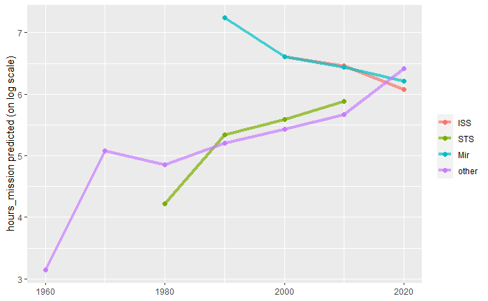

This is for the tree model. The bagged tree model is able to average over time.

Compare with the mars model.

```r
new_astronauts %>%
  bind_cols(predict(mars_rs, new_astronauts)) %>%
  ggplot(aes(year_of_mission, .pred, color = in_orbit)) +
  geom_line(size = 1.5, alpha = .7) +
  geom_point(size = 2) +
  labs(x = NULL,
       color = NULL,
       y = "hours_mission predicted (on log scale)")
```

[output not shown]

This shows what kind of nice results we can get using boot strap aggregatin (bagging!) Non linear effects from time and different types of categorical predictors.

Bagging can reduce overfitting, decrease variance and increase stability.

End!